## Install Packages

```r
#install.packages("forecast")
#install.packages("graphics")
#install.packages("TTR")
#install.packages("TSA")
```

## Pemanggilan Packages

```r
library("forecast")
```

```r
library("graphics")
library("TTR")
library("TSA")
```

## Memanggil data dari github

```r
library(rio)
data1 <- import("https://raw.githubusercontent.com/Safwa40/MPDW/main/Pertemuan%201/Data1.csv")
```

## Eksplorasi Data

```r
View(data1)
str(data1)
```

```
## 'data.frame':    128 obs. of  2 variables:
##  $ Periodebulan     : int  1 2 3 4 5 6 7 8 9 10 ...
##  $ Batubara(USD/ton): num  87.5 88.3 90.1 88.6 85.3 ...
```

```r
dim(data1)
```

```
## [1] 128   2
```

## Merubah Data jadi Time Series

```r
data1ts <- ts(data1$'Batubara(USD/ton)')
print(data1ts)
```

```
## Time Series:
## Start = 1
## End = 128
## Frequency = 1
##   [1]  87.55  88.35  90.09  88.56  85.33  84.87  81.69  76.70  76.89  76.61
##  [11]  78.13  80.31  81.90  80.44  77.01  74.81  73.60  73.64  72.45  70.29
##  [21]  69.69  67.26  65.70  64.65  63.84  62.92  67.76  64.48  61.08  59.59
##  [31]  59.16  59.14  58.21  57.39  54.43  53.51  53.20  50.92  51.62  52.32
##  [41]  51.20  51.81  53.00  58.37  63.93  69.07  84.89 101.69  86.23  83.32
##  [51]  81.90  82.51  83.81  75.46  78.95  83.97  92.03  93.99  94.80  94.04
##  [61]  95.54 100.69 101.86  94.75  89.53  96.61 104.65 107.83 104.81 100.89
##  [71]  97.90  92.51  92.41  91.80  90.57  88.85  81.86  81.48  71.92  72.67
##  [81]  65.79  64.80  66.27  66.30  65.93  66.89  67.08  65.77  61.11  52.98
##  [91]  52.16  50.34  49.42  51.00  55.71  59.65  75.84  87.79  84.47  86.68
## [101]  89.74 100.33 115.35 130.99 150.03 161.63 215.01 159.79 158.50 188.38
## [111] 203.69 288.40 275.64 323.91 319.00 321.59 319.22 330.97 308.20 281.48
## [121] 305.21 277.05 283.08 265.26 206.16 191.26 191.60 179.90
```

## Melihat Analisis Datanya

```r
summary(data1ts)
```

```
##    Min. 1st Qu.  Median    Mean 3rd Qu.    Max.
##   49.42   65.78   82.20  108.26  100.74  330.97
```

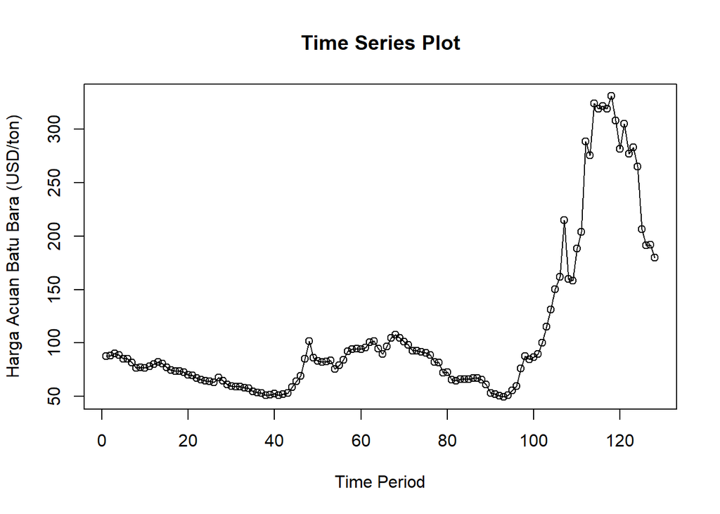

```r
ts.plot(data1ts, xlab="Time Period", ylab="Harga Acuan Batu Bara (USD/ton)",
        main = "Time Series Plot")
points(data1ts)
```

Pola plot tersebut tidak berbentuk musiman ataupun konstan sehingga dicoba pemulusan menggunakan DMA dan DES karena SMA dan SES lebih cocok untuk data yang stasioner

#Double Moving Average

Pembagian Data Latih da Data Uji

```r
#Pembagian data latih dan data uji dilakukan dengan perbandingan 80% data latih dan 20% data uji.
#membagi data latih dan data uji
training_ma <- data1[1:102,]
testing_ma <- data1[103:128,]
train_ma.ts <- ts(training_ma$`Batubara(USD/ton)`)
test_ma.ts <- ts(testing_ma$`Batubara(USD/ton)`)
```

Eksplorasi data dilakukan pada keseluruhan data, data latih serta data uji menggunakan plot data deret waktu.

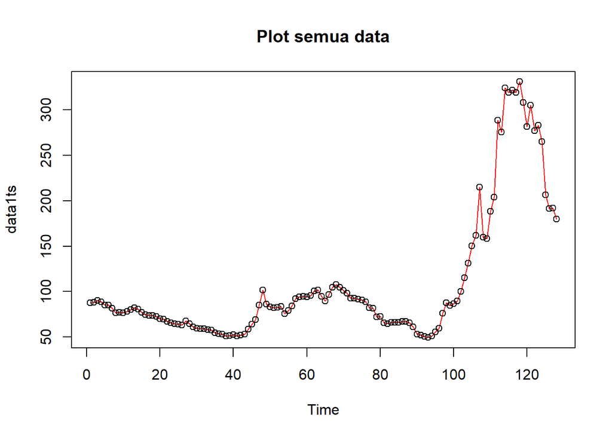

```r
#eksplorasi keseluruhan data
plot(data1ts, col="red",main="Plot semua data")
points(data1ts)
```

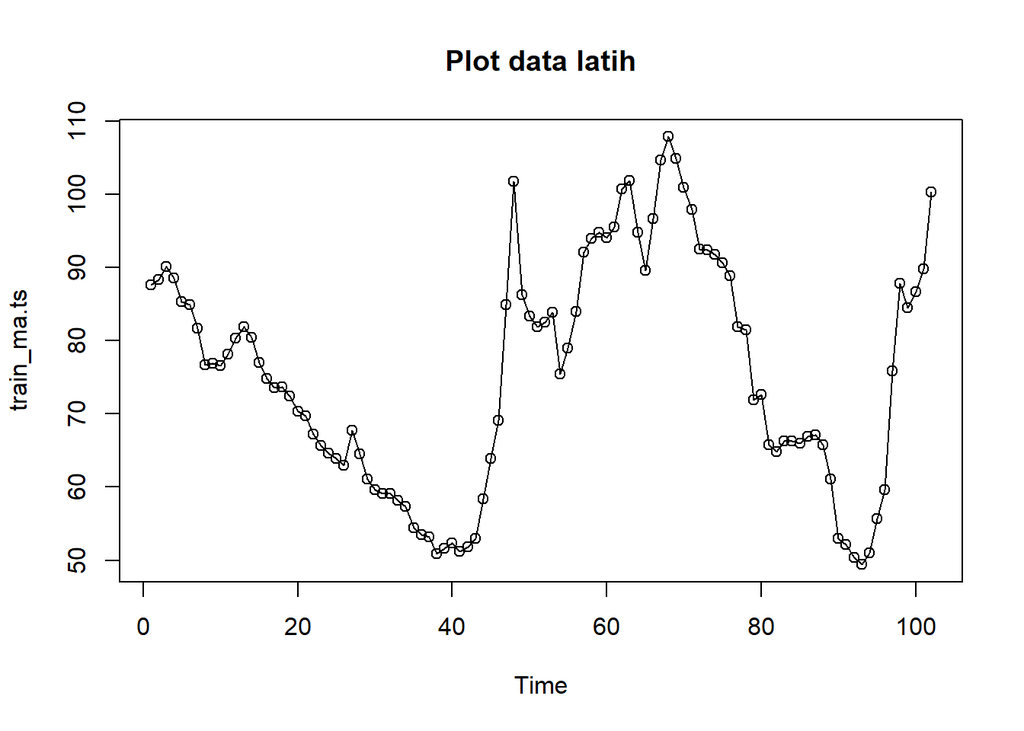

```r
#eksplorasi data latih
plot(train_ma.ts, col="black",main="Plot data latih")
points(train_ma.ts)
```

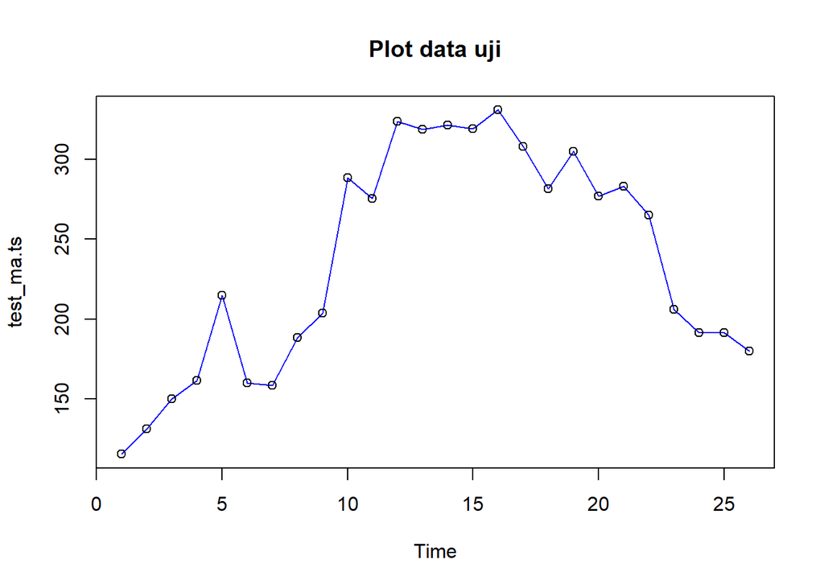

```r
#eksplorasi data uji
plot(test_ma.ts, col="blue",main="Plot data uji")
points(test_ma.ts)
```

#Double Moving Average (DMA)# Metode pemulusan Double Moving Average (DMA) pada dasarnya mirip dengan SMA. Namun demikian, metode ini lebih cocok digunakan untuk pola data trend. Proses pemulusan dengan rata rata dalam metode ini dilakukan sebanyak 2 kali.

```r
data.sma<-SMA(train_ma.ts, n=2)
data.sma
```

```
## Time Series:
## Start = 1
## End = 102
## Frequency = 1
##   [1]      NA  87.950  89.220  89.325  86.945  85.100  83.280  79.195  76.795
##  [10]  76.750  77.370  79.220  81.105  81.170  78.725  75.910  74.205  73.620
##  [19]  73.045  71.370  69.990  68.475  66.480  65.175  64.245  63.380  65.340
##  [28]  66.120  62.780  60.335  59.375  59.150  58.675  57.800  55.910  53.970
##  [37]  53.355  52.060  51.270  51.970  51.760  51.505  52.405  55.685  61.150
##  [46]  66.500  76.980  93.290  93.960  84.775  82.610  82.205  83.160  79.635
##  [55]  77.205  81.460  88.000  93.010  94.395  94.420  94.790  98.115 101.275
##  [64]  98.305  92.140  93.070 100.630 106.240 106.320 102.850  99.395  95.205
##  [73]  92.460  92.105  91.185  89.710  85.355  81.670  76.700  72.295  69.230
##  [82]  65.295  65.535  66.285  66.115  66.410  66.985  66.425  63.440  57.045
##  [91]  52.570  51.250  49.880  50.210  53.355  57.680  67.745  81.815  86.130
## [100]  85.575  88.210  95.035
```

```r
dma <- SMA(data.sma, n = 2)
At <- 2*data.sma - dma
Bt <- 2/(2-1)*(data.sma - dma)
data.dma<- At+Bt
data.ramal2<- c(NA, data.dma)

t = 1:26
f = c()

for (i in t) {
  f[i] = At[length(At)] + Bt[length(Bt)]*(i)
}
data.gab2 <- cbind(aktual = c(train_ma.ts,rep(NA,26)), pemulusan1 = c(data.sma,rep(NA,26)),pemulusan2 = c(data.dma, rep(NA,26)),At = c(At, rep(NA,26)), Bt = c(Bt,rep(NA,26)),ramalan = c(data.ramal2, f[-1]))
data.gab2
```

```
##        aktual pemulusan1 pemulusan2       At     Bt  ramalan
##   [1,]  87.55         NA         NA       NA     NA       NA
##   [2,]  88.35     87.950         NA       NA     NA       NA
##   [3,]  90.09     89.220    91.1250  89.8550  1.270       NA
##   [4,]  88.56     89.325    89.4825  89.3775  0.105  91.1250
##   [5,]  85.33     86.945    83.3750  85.7550 -2.380  89.4825
##   [6,]  84.87     85.100    82.3325  84.1775 -1.845  83.3750
##   [7,]  81.69     83.280    80.5500  82.3700 -1.820  82.3325
##   [8,]  76.70     79.195    73.0675  77.1525 -4.085  80.5500
##   [9,]  76.89     76.795    73.1950  75.5950 -2.400  73.0675
##  [10,]  76.61     76.750    76.6825  76.7275 -0.045  73.1950
##  [11,]  78.13     77.370    78.3000  77.6800  0.620  76.6825
##  [12,]  80.31     79.220    81.9950  80.1450  1.850  78.3000
##  [13,]  81.90     81.105    83.9325  82.0475  1.885  81.9950
##  [14,]  80.44     81.170    81.2675  81.2025  0.065  83.9325
```

[output cut: 114 more lines]

Hasil pemulusan menggunakan metode DMA divisualisasikan sebagai berikut

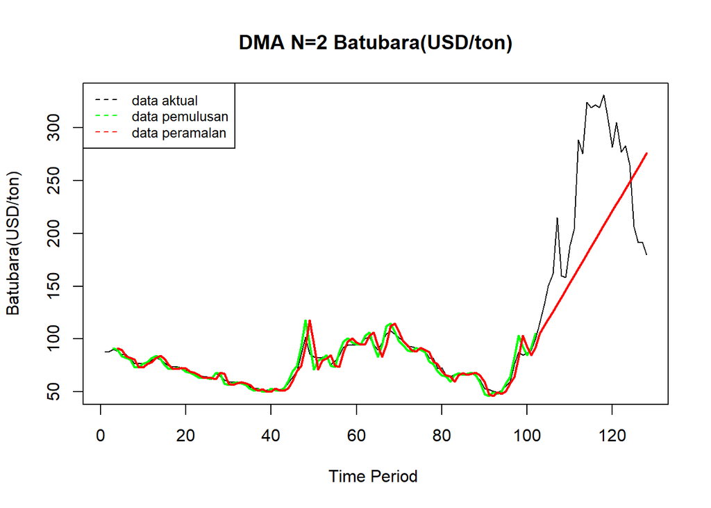

```r
ts.plot(data1ts, xlab="Time Period ", ylab="Batubara(USD/ton)", main= "DMA N=2 Batubara(USD/ton)")
lines(data.gab2[,3],col="green",lwd=2)
lines(data.gab2[,6],col="red",lwd=2)
legend("topleft",c("data aktual","data pemulusan","data peramalan"), lty=8, col=c("black","green","red"), cex=0.8)
```

Dilakukan pengujian data latih dan data uji dengan SSE, MSE, dan MAPE

```r
#Menghitung nilai keakuratan data latih
error_train.dma = train_ma.ts-data.ramal2[1:length(train_ma.ts)]
SSE_train.dma = sum(error_train.dma[4:length(train_ma.ts)]^2)
MSE_train.dma = mean(error_train.dma[4:length(train_ma.ts)]^2)
MAPE_train.dma = mean(abs((error_train.dma[4:length(train_ma.ts)]/train_ma.ts[4:length(train_ma.ts)])*100))

akurasi_train.dma <- matrix(c(SSE_train.dma, MSE_train.dma, MAPE_train.dma))
row.names(akurasi_train.dma)<- c("SSE", "MSE", "MAPE")
colnames(akurasi_train.dma) <- c("Akurasi m = 2")
akurasi_train.dma
```

```
##      Akurasi m = 2
## SSE    3538.246412
## MSE      35.739863
## MAPE      5.099316
```

```r
#Menghitung nilai keakuratan data uji
error_test.dma = test_ma.ts-data.gab2[103:128,6]
SSE_test.dma = sum(error_test.dma^2)
MSE_test.dma = mean(error_test.dma^2)
MAPE_test.dma = mean(abs((error_test.dma/test_ma.ts*100)))

akurasi_test.dma <- matrix(c(SSE_test.dma, MSE_test.dma, MAPE_test.dma))
row.names(akurasi_test.dma)<- c("SSE", "MSE", "MAPE")
colnames(akurasi_test.dma) <- c("Akurasi m = 2")
akurasi_test.dma
```

```
##      Akurasi m = 2
## SSE   166768.37731
## MSE     6414.16836
## MAPE      27.38683
```

Kedua nilai baik data latih memiliki nilai MAPE <10% sehingga data tersebut dapat dikategorikan sangat baik sedangkan data uji memiliki nilai lebih dari 10% pada m=2.